# Model Interpretation

Bodo Winter

16/12/2019

## Preliminaries

Load packages:

```r
library(tidyverse)
library(brms)
library(gridExtra)
```

Load language data for plotting:

```r
lang_info <- read_csv('../data/language_info.csv')
field_info <- read_csv('../data/language_info_field.csv')
```

Load ggplot2 theme:

```r
source('theme_timo.R')
```

Load models:

```r
load('../models/main_mdl.RData')
load('../models/field_animacy_mdl.RData')
load('../models/field_mdl.RData')
```

## Posterior predictive checks:

Perform posterior predictive checks:

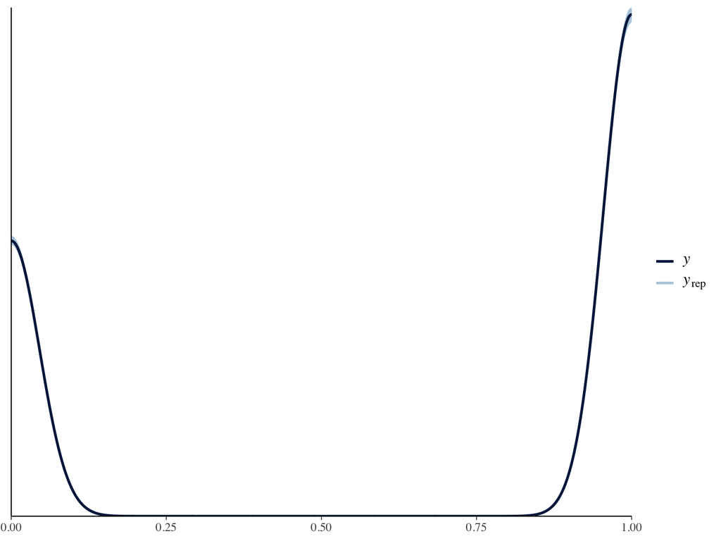

```r
pp_check(main_mdl, nsamples = 1000)
```

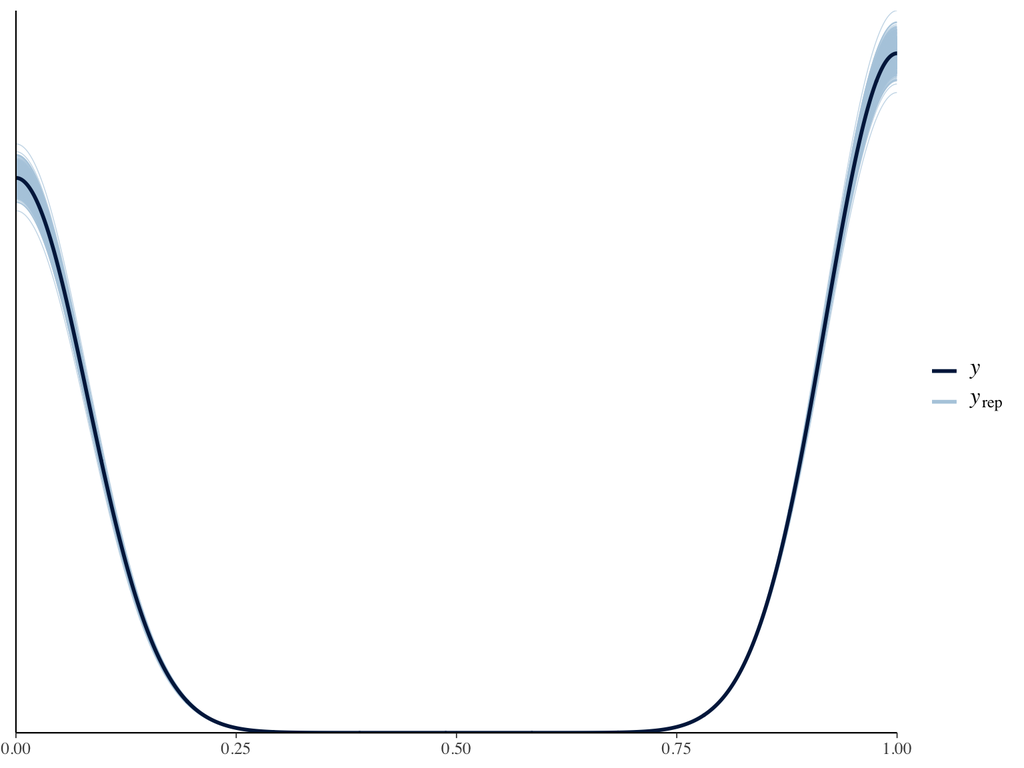

```r
pp_check(field_mdl, nsamples = 1000)
```

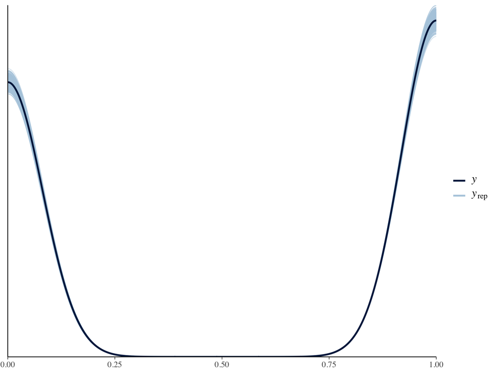

```r
pp_check(field_animacy_mdl, nsamples = 1000)
```

They all look pretty good! (The black line falls well within the rest of the lines)

## Summarize models, first accuracy-only, without consideration of animacy:

Summarize models, first the main model for the online data:

```r
summary(main_mdl)
```

```
##  Family: bernoulli
##   Links: mu = logit
## Formula: ACC ~ 1 + (1 | ID) + (1 | Meaning) + (1 | UniqueItem) + (1 | Team) + (1 | Language) + (1 | Genus)
##    Data: web (Number of observations: 75391)
## Samples: 4 chains, each with iter = 4000; warmup = 2000; thin = 1;
##          total post-warmup samples = 8000
##
## Group-Level Effects:
## ~Genus (Number of levels: 9)
##               Estimate Est.Error l-95% CI u-95% CI Rhat Bulk_ESS Tail_ESS
## sd(Intercept)     0.24      0.14     0.02     0.56 1.00     1835     1847
##
## ~ID (Number of levels: 843)
##               Estimate Est.Error l-95% CI u-95% CI Rhat Bulk_ESS Tail_ESS
## sd(Intercept)     0.33      0.01     0.30     0.35 1.00     3927     5428
##
## ~Language (Number of levels: 26)
##               Estimate Est.Error l-95% CI u-95% CI Rhat Bulk_ESS Tail_ESS
## sd(Intercept)     0.26      0.05     0.17     0.37 1.00     2124     3647
##
## ~Meaning (Number of levels: 30)
##               Estimate Est.Error l-95% CI u-95% CI Rhat Bulk_ESS Tail_ESS
## sd(Intercept)     1.12      0.17     0.84     1.50 1.01     2179     3909
##
## ~Team (Number of levels: 11)
##               Estimate Est.Error l-95% CI u-95% CI Rhat Bulk_ESS Tail_ESS
## sd(Intercept)     0.13      0.11     0.01     0.40 1.00     2055     4034
##
## ~UniqueItem (Number of levels: 90)
##               Estimate Est.Error l-95% CI u-95% CI Rhat Bulk_ESS Tail_ESS
## sd(Intercept)     0.56      0.06     0.46     0.68 1.00     2678     4468
##
## Population-Level Effects:
##           Estimate Est.Error l-95% CI u-95% CI Rhat Bulk_ESS Tail_ESS
## Intercept     0.65      0.25     0.16     1.15 1.01     1657     3092
##
## Samples were drawn using sampling(NUTS). For each parameter, Bulk_ESS
## and Tail_ESS are effective sample size measures, and Rhat is the potential
## scale reduction factor on split chains (at convergence, Rhat = 1).
```

What is the estimated average accuracy?

```r
plogis(fixef(main_mdl)[, 1])
```

```
## [1] 0.6576129
```

```r
# Lower bound of 95% CI:

plogis(fixef(main_mdl)[, 3])
```

```
## [1] 0.5392046
```

```r
# Upper bound of 95% CI:

plogis(fixef(main_mdl)[, 4])
```

```
## [1] 0.7593025
```

The lower threshold does not include chance level (= 1/6).

Extract posterior samples:

```r
main_samples <- posterior_samples(main_mdl)
field_samples <- posterior_samples(field_mdl)
```

What is the posterior probability of this being above the chancel threshold of 1/6?

```r
myposts <- main_samples$b_Intercept
sum(myposts > qlogis(1/6)) / length(myposts)
```

```
## [1] 1
```

100%, not a single posterior sample below the chance threshold of 1/6.

What is the posterior probability of the speaker random effect being larger than the language random effect?

```r
sum(main_samples$sd_ID__Intercept > main_samples$sd_Language__Intercept) / nrow(main_samples)
```

```
## [1] 0.9115
```

Check the same for the field data:

```r
summary(field_mdl)
```

```
##  Family: bernoulli
##   Links: mu = logit
## Formula: ACC ~ 1 + (1 | ID) + (1 | Meaning) + (1 | UniqueItem) + (1 | Team) + (1 | Language)
##    Data: field (Number of observations: 5143)
## Samples: 4 chains, each with iter = 4000; warmup = 2000; thin = 1;
##          total post-warmup samples = 8000
##
## Group-Level Effects:
## ~ID (Number of levels: 143)
##               Estimate Est.Error l-95% CI u-95% CI Rhat Bulk_ESS Tail_ESS
## sd(Intercept)     0.57      0.06     0.47     0.69 1.00     3372     4890
##
## ~Language (Number of levels: 7)
##               Estimate Est.Error l-95% CI u-95% CI Rhat Bulk_ESS Tail_ESS
## sd(Intercept)     0.87      0.38     0.43     1.81 1.00     2696     3680
##
## ~Meaning (Number of levels: 12)
##               Estimate Est.Error l-95% CI u-95% CI Rhat Bulk_ESS Tail_ESS
## sd(Intercept)     1.11      0.36     0.53     1.95 1.00     1902     1842
##
## ~Team (Number of levels: 7)
##               Estimate Est.Error l-95% CI u-95% CI Rhat Bulk_ESS Tail_ESS
## sd(Intercept)     0.27      0.25     0.01     0.91 1.00     2644     4240
##
## ~UniqueItem (Number of levels: 36)
##               Estimate Est.Error l-95% CI u-95% CI Rhat Bulk_ESS Tail_ESS
## sd(Intercept)     0.94      0.16     0.67     1.31 1.00     2184     2433
##
## Population-Level Effects:
##           Estimate Est.Error l-95% CI u-95% CI Rhat Bulk_ESS Tail_ESS
## Intercept     0.08      0.55    -1.03     1.15 1.00     2182     3212
##
## Samples were drawn using sampling(NUTS). For each parameter, Bulk_ESS
## and Tail_ESS are effective sample size measures, and Rhat is the potential
## scale reduction factor on split chains (at convergence, Rhat = 1).
```

What is the estimated average accuracy?

```r
plogis(fixef(field_mdl)[, 1])
```

```
## [1] 0.519293
```

```r
# Lower bound of 95% CI:

plogis(fixef(field_mdl)[, 3])
```

```
## [1] 0.2634167
```

```r
# Upper bound of 95% CI:

plogis(fixef(field_mdl)[, 4])
```

```
## [1] 0.7594953
```

The lower threshold does not include chance level (= 1/12).

What is the posterior probability of this being above the chancel threshold of 1/12?

```r
myposts <- field_samples$b_Intercept
sum(myposts > qlogis(1/12)) / length(myposts)
```

```
## [1] 0.9995
```

99%, very few posterior samples below the chance threshold of 1/12.

## Summarize models, with animacy predictors:

Check same for field model:

```r
summary(field_animacy_mdl)
```

```
##  Family: bernoulli
##   Links: mu = logit
## Formula: ACC ~ 1 + Animacy + (1 + Animacy | ID) + (1 | Meaning) + (1 | UniqueItem) + (1 | Team) + (1 + Animacy | Language)
##    Data: field (Number of observations: 5143)
## Samples: 4 chains, each with iter = 4000; warmup = 2000; thin = 1;
##          total post-warmup samples = 8000
##
## Group-Level Effects:
## ~ID (Number of levels: 143)
##                                 Estimate Est.Error l-95% CI u-95% CI Rhat
## sd(Intercept)                       0.51      0.07     0.37     0.65 1.00
## sd(Animacyinanimate)                0.37      0.14     0.10     0.63 1.01
## cor(Intercept,Animacyinanimate)     0.24      0.35    -0.37     0.94 1.01
##                                 Bulk_ESS Tail_ESS
## sd(Intercept)                       4382     6125
## sd(Animacyinanimate)                 663     2005
## cor(Intercept,Animacyinanimate)     1134     1521
##
## ~Language (Number of levels: 7)
##                                 Estimate Est.Error l-95% CI u-95% CI Rhat
## sd(Intercept)                       0.78      0.35     0.37     1.68 1.00
## sd(Animacyinanimate)                0.39      0.25     0.04     1.02 1.00
## cor(Intercept,Animacyinanimate)     0.48      0.40    -0.50     0.97 1.00
##                                 Bulk_ESS Tail_ESS
## sd(Intercept)                       3470     4714
## sd(Animacyinanimate)                2659     2438
## cor(Intercept,Animacyinanimate)     5503     5119
##
## ~Meaning (Number of levels: 12)
##               Estimate Est.Error l-95% CI u-95% CI Rhat Bulk_ESS Tail_ESS
## sd(Intercept)     0.52      0.30     0.04     1.18 1.00     1190     2127
##
## ~Team (Number of levels: 7)
##               Estimate Est.Error l-95% CI u-95% CI Rhat Bulk_ESS Tail_ESS
## sd(Intercept)     0.27      0.25     0.01     0.92 1.00     2248     4225
##
## ~UniqueItem (Number of levels: 36)
##               Estimate Est.Error l-95% CI u-95% CI Rhat Bulk_ESS Tail_ESS
## sd(Intercept)     0.95      0.15     0.69     1.27 1.00     2403     4049
##
## Population-Level Effects:
##                  Estimate Est.Error l-95% CI u-95% CI Rhat Bulk_ESS Tail_ESS
## Intercept            0.88      0.49    -0.10     1.85 1.00     3230     4150
## Animacyinanimate    -1.63      0.49    -2.58    -0.60 1.00     3655     4357
##
## Samples were drawn using sampling(NUTS). For each parameter, Bulk_ESS
## and Tail_ESS are effective sample size measures, and Rhat is the potential
## scale reduction factor on split chains (at convergence, Rhat = 1).
```

Check coefficients, first the estimate (times two because sum-coded):

```r
round(fixef(field_animacy_mdl)[2, 1] * 2, 2)
```

```
## [1] -3.27
```

The standard error also needs to be multiplied by two:

```r
round(fixef(field_animacy_mdl)[2, 2] * 2, 2)
```

```
## [1] 0.99
```

The odds:

```r
round(exp(fixef(field_animacy_mdl)[2, 1] * 2), 2)
```

```
## [1] 0.04
```

The posterior probability of the animacy coefficient being above zero:

```r
animacy_samples <- posterior_samples(field_animacy_mdl)
sum(animacy_samples$b_Animacy1 > 0) / nrow(animacy_samples)
```

```
## [1] 0
```

## Plotting the model estimates, online experiment:

Getting the posteriors per language:

```r
lang_samples <- select(main_samples, contains('Language'))
head(lang_samples)
```

```
##   sd_Language__Intercept r_Language[AL,Intercept] r_Language[AM,Intercept]
## 1              0.2577229               -0.5031709              -0.02606881
## 2              0.2037834               -0.5787322              -0.16687087
## 3              0.2079965               -0.3363909              -0.11886740
## 4              0.3501281               -0.2959777              -0.09256774
## 5              0.3563625               -0.3669878              -0.09971820
## 6              0.2163920               -0.5210541              -0.05403359
##   r_Language[CN,Intercept] r_Language[DE,Intercept] r_Language[DK,Intercept]
## 1               0.14377703                0.5126893                0.4575348
## 2              -0.06633821                0.3999934                0.3677868
## 3               0.05358322                0.4062730                0.4057971
## 4              -0.42489744                0.4159791                0.2539993
## 5              -0.41612335                0.4451225                0.2004794
## 6              -0.24982016                0.3311034                0.3029525
##   r_Language[EE,Intercept] r_Language[EN,Intercept] r_Language[ES,Intercept]
```

[output cut: 48 more lines]

Get rid of the first, which is across all of them:

```r
lang_samples <- lang_samples[, -1]
```

The genus information needs to be added for each language. First, extract the family info:

```r
benue_congo <- main_samples$`r_Genus[Benue-Congo,Intercept]`
finno_ugric <- main_samples$`r_Genus[Finno-Ugric,Intercept]`
IE <- main_samples$`r_Genus[IE,Intercept]`
korean <- main_samples$`r_Genus[Korean,Intercept]`
kartvelian <- main_samples$`r_Genus[Kartvelian,Intercept]`
sino_tibetan <- main_samples$`r_Genus[Sino-Tibetan,Intercept]`
tai_kadai <- main_samples$`r_Genus[Tai-Kadai,Intercept]`
turkic <- main_samples$`r_Genus[Turkic,Intercept]`
japanese <- main_samples$`r_Genus[Japanese,Intercept]`
```

Extract intercept:

```r
int <- main_samples$b_Intercept
```

Add the language family estimates and the intercepts to the respective languages:

```r
lang_samples$`r_Language[AL,Intercept]` <- lang_samples$`r_Language[AL,Intercept]` + IE + int
lang_samples$`r_Language[CN,Intercept]` <- lang_samples$`r_Language[CN,Intercept]` + sino_tibetan + int
lang_samples$`r_Language[DE,Intercept]` <- lang_samples$`r_Language[DE,Intercept]` + IE + int
lang_samples$`r_Language[DK,Intercept]` <- lang_samples$`r_Language[DK,Intercept]` + IE + int

lang_samples$`r_Language[EE,Intercept]` <- lang_samples$`r_Language[EE,Intercept]` + finno_ugric + int
lang_samples$`r_Language[EN,Intercept]` <- lang_samples$`r_Language[EN,Intercept]` + IE + int
lang_samples$`r_Language[ES,Intercept]` <- lang_samples$`r_Language[ES,Intercept]` + IE + int
lang_samples$`r_Language[FA,Intercept]` <- lang_samples$`r_Language[FA,Intercept]` + IE + int
lang_samples$`r_Language[FI,Intercept]` <- lang_samples$`r_Language[FI,Intercept]` + finno_ugric + int

lang_samples$`r_Language[FR,Intercept]` <- lang_samples$`r_Language[FR,Intercept]` + IE + int
lang_samples$`r_Language[GE,Intercept]` <- lang_samples$`r_Language[GE,Intercept]` + kartvelian + int
lang_samples$`r_Language[GR,Intercept]` <- lang_samples$`r_Language[GR,Intercept]` + IE + int
lang_samples$`r_Language[HU,Intercept]` <- lang_samples$`r_Language[HU,Intercept]` + finno_ugric + int
lang_samples$`r_Language[IT,Intercept]` <- lang_samples$`r_Language[IT,Intercept]` + IE + int

lang_samples$`r_Language[JP,Intercept]` <- lang_samples$`r_Language[JP,Intercept]` + japanese + int
lang_samples$`r_Language[KR,Intercept]` <- lang_samples$`r_Language[KR,Intercept]` + korean + int
lang_samples$`r_Language[PL,Intercept]` <- lang_samples$`r_Language[PL,Intercept]` + IE + int
lang_samples$`r_Language[PT,Intercept]` <- lang_samples$`r_Language[PT,Intercept]` + IE + int
lang_samples$`r_Language[RO,Intercept]` <- lang_samples$`r_Language[RO,Intercept]` + IE + int

lang_samples$`r_Language[RU,Intercept]` <- lang_samples$`r_Language[RU,Intercept]` + IE + int
lang_samples$`r_Language[SE,Intercept]` <- lang_samples$`r_Language[SE,Intercept]` + IE + int
lang_samples$`r_Language[TH,Intercept]` <- lang_samples$`r_Language[TH,Intercept]` + tai_kadai + int
lang_samples$`r_Language[TR,Intercept]` <- lang_samples$`r_Language[TR,Intercept]` + turkic + int
lang_samples$`r_Language[ZU,Intercept]` <- lang_samples$`r_Language[ZU,Intercept]` + benue_congo + int
```

Compute 95% CI for all of these:

```r
lower_CIs <- apply(lang_samples, FUN = function(x) quantile(x, 0.025), MARGIN = 2)
upper_CIs <- apply(lang_samples, FUN = function(x) quantile(x, 0.975), MARGIN = 2)
post_mean <- colMeans(lang_samples)
```

Put those into a table, with logistic transform back to probabilities:

```r
lang_intervals <- tibble(Language = str_extract(colnames(lang_samples), '[A-Z]{2,2}'),
                         lower_CI = plogis(lower_CIs),
                         upper_CI = plogis(upper_CIs),
                         M = plogis(post_mean))
```

Merge with name for plotting:

```r
lang_intervals$Name <- lang_info[match(lang_intervals$Language, lang_info$Language), ]$Name
```

Change “English UK” label to just “English”:

```r
lang_intervals[lang_intervals$Language == 'EN', ]$Name <- 'English'
```

“Amharic” is actually “Armenian”:

```r
lang_intervals[lang_intervals$Name == 'Amharic', ]$Name <- 'Armenian'
```

Change the order of language levels according to the posterior mean:

```r
lang_intervals <- arrange(lang_intervals, M)
lang_intervals <- mutate(lang_intervals,
                         Name = factor(Name, levels = lang_intervals$Name))
```

Make a plot with accuracy per language:

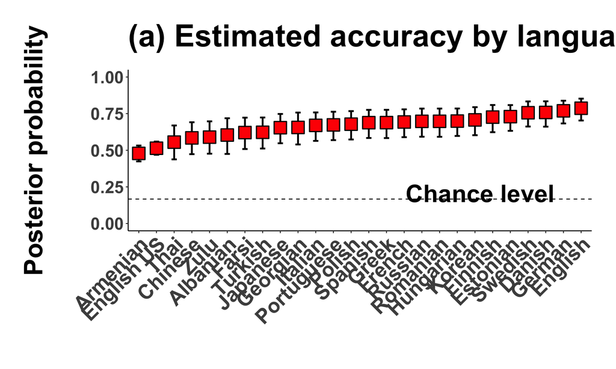

```r
lang_plot <- ggplot(data = lang_intervals,
                    mapping = aes(x = Name, y = M,
                                  ymin = lower_CI, ymax = upper_CI)) +
  geom_errorbar(width = 0.3, lwd = 1) +
  geom_point(pch = 22, size = 7, fill = 'red', col = 'black', stroke = 1) +
  geom_hline(yintercept = 1/6, linetype = 2) +
  theme_timo +
  annotate('text', label = 'Chance level', x = 24.5, y = 1/6 + 0.04,
           size = 10, fontface = 'bold', hjust = 1) +
  coord_cartesian(ylim = c(0, 1)) +
  theme(axis.text.x = element_text(angle = 45, hjust = 1, vjust = 1,
                                   face = 'bold', size = 24),
        axis.title.y = element_text(margin = margin(t = 0, r = 50, b = 0, l = 0),
                                    size = 30),
        axis.text.y = element_text(face = 'bold', size = 20),
        plot.title = element_text(face = 'bold', size = 36, hjust = 0,
                                  margin = margin(t = 0, r = 0, b = 20, l = 0))) +
  labs(title = '(a) Estimated accuracy by language',
       x = '', y = 'Posterior probability')
lang_plot
```

Getting the posteriors per meaning:

```r
meaning_samples <- select(main_samples, contains('Meaning'))
head(meaning_samples)
```

```
##   sd_Meaning__Intercept r_Meaning[bad,Intercept] r_Meaning[big,Intercept]
## 1              1.235441                0.5308346               0.06938551
## 2              1.257633                0.2760996               0.03229290
## 3              1.157755                0.5309300               0.41754255
## 4              1.093497               -0.2035639              -0.25448274
## 5              1.086202               -0.2611809              -0.30507249
## 6              1.016927                0.1907607               0.17532303
##   r_Meaning[child,Intercept] r_Meaning[cook,Intercept] r_Meaning[cut,Intercept]
## 1                   1.537108                -0.2407609                0.7570210
## 2                   1.272354                -0.5382997                0.5280617
## 3                   0.776606                -0.4499544               -0.0719097
## 4                   1.253064                -0.5983464                0.3445190
## 5                   1.198884                -0.5762872                0.3373006
## 6                   1.078645                -0.6465930                0.2205657
##   r_Meaning[deer,Intercept] r_Meaning[dull,Intercept] r_Meaning[eat,Intercept]
```

[output cut: 76 more lines]

Get rid of the first, which is across all of them:

```r
meaning_samples <- meaning_samples[, -1]
```

Add the intercept to this one as well:

```r
for (i in 1:ncol(meaning_samples)) {
  meaning_samples[, i] <- meaning_samples[, i] + int
}
```

Compute 95% CI for all of these:

```r
lower_CIs <- apply(meaning_samples,
                   FUN = function(x) quantile(x, 0.025), MARGIN = 2)
upper_CIs <- apply(meaning_samples,
                   FUN = function(x) quantile(x, 0.975), MARGIN = 2)
post_mean <- colMeans(meaning_samples)
```

Put those into a table, with logistic transform back to probabilities:

```r
meaning_intervals <- tibble(Meaning = str_extract(colnames(meaning_samples),
                                                  '\\[[a-z]{2,10}'),
                            lower_CI = plogis(lower_CIs),
                            upper_CI = plogis(upper_CIs),
                            M = plogis(post_mean))
meaning_intervals <- mutate(meaning_intervals,
                            Meaning = str_replace(Meaning, '\\[', ''))
```

Change the order of language levels according to the posterior mean:

```r
meaning_intervals <- arrange(meaning_intervals, M)
meaning_intervals <- mutate(meaning_intervals,
                            Meaning = factor(Meaning,
                                             levels = meaning_intervals$Meaning))
```

Make a plot with accuracy per meaning:

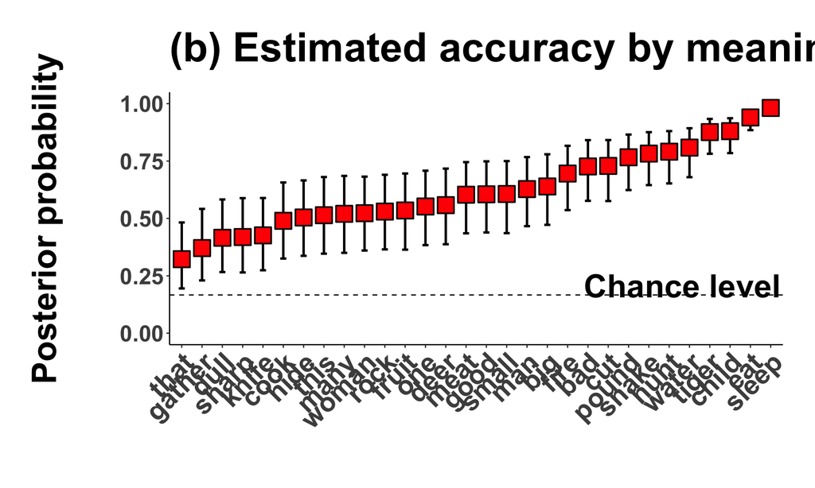

```r
meaning_plot <- ggplot(data = meaning_intervals,
                    mapping = aes(x = Meaning, y = M,
                                  ymin = lower_CI, ymax = upper_CI)) +
  geom_errorbar(width = 0.3, lwd = 1) +
  geom_point(pch = 22, size = 7, fill = 'red', col = 'black', stroke = 1) +
  geom_hline(yintercept = 1/6, linetype = 2) +
  theme_timo +
  annotate('text', label = 'Chance level', x = 30.5, y = 1/6 + 0.04,
           size = 10, fontface = 'bold', hjust = 1) +
  coord_cartesian(ylim = c(0, 1)) +
  theme(axis.text.x = element_text(angle = 45, hjust = 1, vjust = 1,
                                   face = 'bold', size = 24),
        axis.title.y = element_text(margin = margin(t = 0, r = 50, b = 0, l = 0),
                                    size = 30),
        axis.text.y = element_text(face = 'bold', size = 20),
        plot.title = element_text(face = 'bold', size = 36, hjust = 0,
                                  margin = margin(t = 0, r = 0, b = 20, l = 0))) +
  labs(title = '(b) Estimated accuracy by meaning',
       x = '', y = 'Posterior probability')
meaning_plot
```

Put both together:

[figure not shown]

```r
my_layout <- rbind(c(1, 1, 1, 1, 1, 1, 1, 1, NA),
                   c(1, 1, 1, 1, 1, 1, 1, 1, NA),
                   c(1, 1, 1, 1, 1, 1, 1, 1, NA),
                   c(1, 1, 1, 1, 1, 1, 1, 1, NA),
                   c(1, 1, 1, 1, 1, 1, 1, 1, NA),
                   c(1, 1, 1, 1, 1, 1, 1, 1, NA),
                   c(1, 1, 1, 1, 1, 1, 1, 1, NA),
                   c(1, 1, 1, 1, 1, 1, 1, 1, NA),
                   c(1, 1, 1, 1, 1, 1, 1, 1, NA),
                   c(1, 1, 1, 1, 1, 1, 1, 1, NA),
                   c(NA, NA, NA, NA, NA, NA, NA, NA, NA),
                   c(2, 2, 2, 2, 2, 2, 2, 2, 2),
                   c(2, 2, 2, 2, 2, 2, 2, 2, 2),
                   c(2, 2, 2, 2, 2, 2, 2, 2, 2),
                   c(2, 2, 2, 2, 2, 2, 2, 2, 2),
                   c(2, 2, 2, 2, 2, 2, 2, 2, 2),
                   c(2, 2, 2, 2, 2, 2, 2, 2, 2),
                   c(2, 2, 2, 2, 2, 2, 2, 2, 2),
                   c(2, 2, 2, 2, 2, 2, 2, 2, 2),
                   c(2, 2, 2, 2, 2, 2, 2, 2, 2),
                   c(2, 2, 2, 2, 2, 2, 2, 2, 2))
multi_plot <- grid.arrange(lang_plot, meaning_plot,
                           layout_matrix = my_layout)
```

```r
ggsave(plot = multi_plot, '../figures/web_models.pdf',
       width = 24, height = 22)
ggsave(plot = multi_plot, '../figures/web_models.png',
       width = 24, height = 22)
```

## Field experiment:

Getting the posteriors per language:

```r
field_lang_samples <- select(field_samples, contains('Language'))
head(field_lang_samples)
```

```
##   sd_Language__Intercept r_Language[BE,Intercept] r_Language[BR,Intercept]
## 1              0.7380925                0.3647437                0.0439523
## 2              0.9004038                0.8503250                0.9798827
## 3              0.8425837                1.1098419                1.1273354
## 4              0.8780263                0.9895490                1.0527981
## 5              0.8131277                1.1469175                1.1486647
## 6              0.6160442                0.8990891                1.0031015
##   r_Language[DE,Intercept] r_Language[PA,Intercept] r_Language[SR,Intercept]
## 1                0.4224489              -0.62131412              -1.12602459
## 2                1.2304191              -0.31342113              -0.55138565
## 3                1.0980203              -0.43926002              -0.87508802
## 4                1.1584150              -0.18341440              -0.70815825
## 5                1.2196405              -0.29850694              -0.07880388
## 6                1.0481022              -0.02736032              -0.40435810
##   r_Language[US,Intercept] r_Language[VA,Intercept]
## 1                0.2994374              -0.43970920
## 2                0.8875377               0.06439854
## 3                1.0620932              -0.15869510
## 4                1.0791574              -0.31386749
## 5                1.3125874               0.31841568
## 6                0.8801170               0.30183859
```

Get rid of the first, which is across all of them:

```r
field_lang_samples <- field_lang_samples[, -1]
```

Add the intercept:

```r
for (i in 1:ncol(field_lang_samples)) {
  field_lang_samples[, i] <- field_lang_samples[, i] + field_samples$b_Intercept
}
```

Compute 95% CI for all of these:

```r
lower_CIs <- apply(field_lang_samples, FUN = function(x) quantile(x, 0.025), MARGIN = 2)
upper_CIs <- apply(field_lang_samples, FUN = function(x) quantile(x, 0.975), MARGIN = 2)
post_mean <- colMeans(field_lang_samples)
```

Put those into a table, with logistic transform back to probabilities:

```r
field_lang_intervals <- tibble(Language = str_extract(colnames(field_lang_samples), '[A-Z]{2,2}'),
                               lower_CI = plogis(lower_CIs),
                               upper_CI = plogis(upper_CIs),
                               M = plogis(post_mean))
```

Add language names for plotting:

```r
field_lang_intervals$Name <- character(nrow(field_lang_intervals))
field_lang_intervals[field_lang_intervals$Language == 'DE', ]$Name <- 'German'
field_lang_intervals[field_lang_intervals$Language == 'US', ]$Name <- 'English (US)'
field_lang_intervals[field_lang_intervals$Language == 'BE', ]$Name <- 'English (UK)'
field_lang_intervals[field_lang_intervals$Language == 'BR', ]$Name <- 'Tashlhiyt Berber'
field_lang_intervals[field_lang_intervals$Language == 'PA', ]$Name <- 'Palikur'
field_lang_intervals[field_lang_intervals$Language == 'VA', ]$Name <- 'Daakie'
field_lang_intervals[field_lang_intervals$Language == 'SR', ]$Name <- 'Brazilian Portuguese'
```

Change the order of language levels according to the posterior mean:

```r
field_lang_intervals <- arrange(field_lang_intervals, M)
field_lang_intervals <- mutate(field_lang_intervals,
                         Name = factor(Name, levels = field_lang_intervals$Name))
```

Make a plot with accuracy per language:

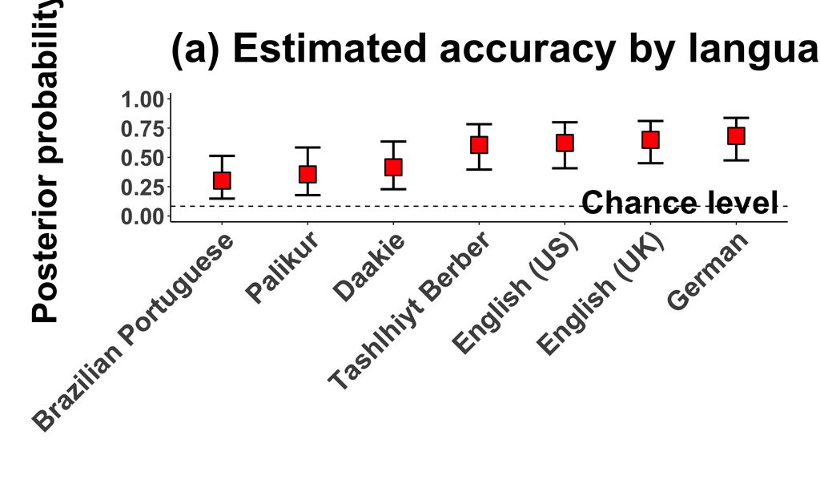

```r
field_lang_plot <- ggplot(data = field_lang_intervals,
                    mapping = aes(x = Name, y = M, ymin = lower_CI, ymax = upper_CI)) +
  geom_errorbar(width = 0.3, lwd = 1) +
  geom_point(pch = 22, size = 7, fill = 'red',
             col = 'black', stroke = 1) +
  geom_hline(yintercept = 1/12, linetype = 2) +
  theme_timo +
  annotate('text', label = 'Chance level', x = 7.5, y = 1/12 + 0.04,
           size = 10, fontface = 'bold', hjust = 1) +
  coord_cartesian(ylim = c(0, 1)) +
  theme(axis.text.x = element_text(angle = 45, hjust = 1, vjust = 1,
                                   face = 'bold', size = 24),
        axis.title.y = element_text(margin = margin(t = 0, r = 50, b = 0, l = 0),
                                    size = 30),
        axis.text.y = element_text(face = 'bold', size = 20),
        plot.title = element_text(face = 'bold', size = 36, hjust = 0,
                                  margin = margin(t = 0, r = 0, b = 20, l = 0))) +
  labs(title = '(a) Estimated accuracy by language',
       x = '', y = 'Posterior probability')
field_lang_plot
```

Getting the posteriors per meaning:

```r
field_meaning_samples <- select(field_samples, contains('Meaning'))
head(field_meaning_samples)
```

```
##   sd_Meaning__Intercept r_Meaning[child,Intercept] r_Meaning[deer,Intercept]
## 1             1.0066618                  1.2631545                 0.2176061
## 2             0.9901765                  1.8689873                 0.5139362
## 3             1.2285066                  2.0827669                 0.9579012
## 4             0.8038550                  1.5788353                 0.8087547
## 5             0.8522044                  0.8723755                 0.6074737
## 6             0.8727976                  1.1945483                 0.8738900
##   r_Meaning[fire,Intercept] r_Meaning[fruit,Intercept]
## 1                -0.9900209                 -0.3156523
## 2                -0.0693758                 -1.8465284
## 3                -0.3240099                 -1.5145281
## 4                -0.6502155                 -1.1817496
## 5                -0.8901270                 -1.6137598
## 6                -0.4827324                 -1.1742209
##   r_Meaning[knife,Intercept] r_Meaning[man,Intercept] r_Meaning[meat,Intercept]
```

[output cut: 27 more lines]

Get rid of the first, which is across all of them:

```r
field_meaning_samples <- field_meaning_samples[, -1]
```

Add the intercept to all of them:

```r
for (i in 1:ncol(field_meaning_samples)) {
  field_meaning_samples[, i] <- field_meaning_samples[, i] + field_samples$b_Intercept
}
```

Compute 95% CI for all of these:

```r
lower_CIs <- apply(field_meaning_samples, FUN = function(x) quantile(x, 0.025), MARGIN = 2)
upper_CIs <- apply(field_meaning_samples, FUN = function(x) quantile(x, 0.975), MARGIN = 2)
post_mean <- colMeans(field_meaning_samples)
```

Put those into a table, with logistic transform back to probabilities:

```r
field_meaning_intervals <- tibble(Meaning = str_extract(colnames(field_meaning_samples), '\\[[a-z]{2,10}'),
                            lower_CI = plogis(lower_CIs),
                            upper_CI = plogis(upper_CIs),
                            M = plogis(post_mean))
field_meaning_intervals <- mutate(field_meaning_intervals,
                            Meaning = str_replace(Meaning, '\\[', ''))
```

Change the order of language levels according to the posterior mean:

```r
field_meaning_intervals <- arrange(field_meaning_intervals, M)
field_meaning_intervals <- mutate(field_meaning_intervals,
                                  Meaning = factor(Meaning, levels = field_meaning_intervals$Meaning))
```

Make a plot with accuracy per meaning:

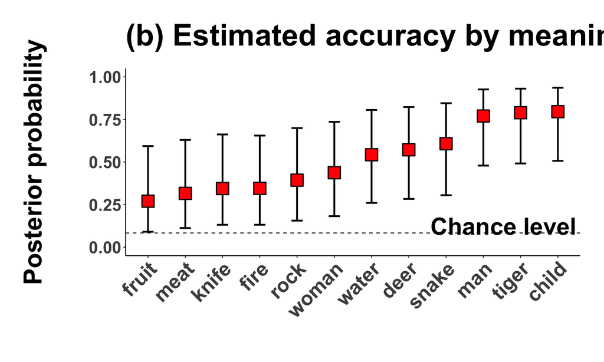

```r
field_meaning_plot <- ggplot(data = field_meaning_intervals,
                    mapping = aes(x = Meaning, y = M, ymin = lower_CI, ymax = upper_CI)) +
  geom_errorbar(width = 0.3, lwd = 1) +
  geom_point(pch = 22, size = 7, fill = 'red',
             col = 'black', stroke = 1) +
  geom_hline(yintercept = 1/12, linetype = 2) +
  theme_timo +
  annotate('text', label = 'Chance level', x = 12.5, y = 1/12 + 0.04,
           size = 10, fontface = 'bold', hjust = 1) +
  coord_cartesian(ylim = c(0, 1)) +
  theme(axis.text.x = element_text(angle = 45, hjust = 1, vjust = 1,
                                   face = 'bold', size = 24),
        axis.title.y = element_text(margin = margin(t = 0, r = 50, b = 0, l = 0),
                                    size = 30),
        axis.text.y = element_text(face = 'bold', size = 20),
        plot.title = element_text(face = 'bold', size = 36, hjust = 0,
                                  margin = margin(t = 0, r = 0, b = 20, l = 0))) +
  labs(title = '(b) Estimated accuracy by meaning',
       x = '', y = 'Posterior probability')
field_meaning_plot
```

Put both together:

[figure not shown]

```r
my_layout <- rbind(c(1, 1, 1, 1, 1, 1, NA, NA, NA),
                   c(1, 1, 1, 1, 1, 1, NA, NA, NA),
                   c(1, 1, 1, 1, 1, 1, NA, NA, NA),
                   c(1, 1, 1, 1, 1, 1, NA, NA, NA),
                   c(1, 1, 1, 1, 1, 1, NA, NA, NA),
                   c(1, 1, 1, 1, 1, 1, NA, NA, NA),
                   c(1, 1, 1, 1, 1, 1, NA, NA, NA),
                   c(1, 1, 1, 1, 1, 1, NA, NA, NA),
                   c(1, 1, 1, 1, 1, 1, NA, NA, NA),
                   c(1, 1, 1, 1, 1, 1, NA, NA, NA),
                   c(NA, NA, NA, NA, NA, NA, NA, NA, NA),
                   c(2, 2, 2, 2, 2, 2, 2, 2, 2),
                   c(2, 2, 2, 2, 2, 2, 2, 2, 2),
                   c(2, 2, 2, 2, 2, 2, 2, 2, 2),
                   c(2, 2, 2, 2, 2, 2, 2, 2, 2),
                   c(2, 2, 2, 2, 2, 2, 2, 2, 2),
                   c(2, 2, 2, 2, 2, 2, 2, 2, 2),
                   c(2, 2, 2, 2, 2, 2, 2, 2, 2),
                   c(2, 2, 2, 2, 2, 2, 2, 2, 2),
                   c(2, 2, 2, 2, 2, 2, 2, 2, 2),
                   c(2, 2, 2, 2, 2, 2, 2, 2, 2))
field_multi_plot <- grid.arrange(field_lang_plot, field_meaning_plot,
                           layout_matrix = my_layout)
```

```r
ggsave(plot = field_multi_plot, '../figures/field_models.pdf',
       width = 20, height = 22)
ggsave(plot = field_multi_plot, '../figures/field_models.png',
       width = 20, height = 22)
```

This completes this analysis.